# Project : White wine Quality

### Objective :

**Explore This dataset and analyse the relationship between quality of wine and different properties of it.**

### Import Packages :

```r
library(ggplot2)
library(GGally)
library(scales)
library(memisc)
library(RColorBrewer)
library(gridExtra)
library(grid)
require(rpart)
require(rpart.plot)
require(nnet)
require(randomForest)
library(dplyr)
require(reshape2)
```

### Loading And Displaying head of data

```r
White_wine <- read.csv("wineQualityWhites.csv")
head(White_wine)
```

| X | fixed.acidity | volatile.acidity | citric.acid | residual.sugar | chlorides | free.sulfur.dioxide | total.sulfur.dioxide | density | pH | sulphates | alcohol | quality |
| --- | --- | --- | --- | --- | --- | --- | --- | --- | --- | --- | --- | --- |
| 1 | 7.0 | 0.27 | 0.36 | 20.7 | 0.045 | 45 | 170 | 1.0010 | 3.00 | 0.45 | 8.8 | 6 |
| 2 | 6.3 | 0.30 | 0.34 | 1.6 | 0.049 | 14 | 132 | 0.9940 | 3.30 | 0.49 | 9.5 | 6 |
| 3 | 8.1 | 0.28 | 0.40 | 6.9 | 0.050 | 30 | 97 | 0.9951 | 3.26 | 0.44 | 10.1 | 6 |
| 4 | 7.2 | 0.23 | 0.32 | 8.5 | 0.058 | 47 | 186 | 0.9956 | 3.19 | 0.40 | 9.9 | 6 |
| 5 | 7.2 | 0.23 | 0.32 | 8.5 | 0.058 | 47 | 186 | 0.9956 | 3.19 | 0.40 | 9.9 | 6 |
| 6 | 8.1 | 0.28 | 0.40 | 6.9 | 0.050 | 30 | 97 | 0.9951 | 3.26 | 0.44 | 10.1 | 6 |

### Description of attributes:

1 - **fixed acidity:** most acids involved with wine or fixed or nonvolatile (do not evaporate readily)

2 - **volatile acidity:** the amount of acetic acid in wine, which at too high of levels can lead to an unpleasant, vinegar taste

3 - **citric acid:** found in small quantities, citric acid can add 'freshness' and flavor to wines

4 - **residual sugar:** the amount of sugar remaining after fermentation stops, it's rare to find wines with less than 1 gram/liter and wines with greater than 45 grams/liter are considered sweet

5 - **chlorides:** the amount of salt in the wine

6 - **free sulfur dioxide:** the free form of SO2 exists in equilibrium between molecular SO2 (as a dissolved gas) and bisulfite ion; it prevents microbial growth and the oxidation of wine

7 - **total sulfur dioxide:** amount of free and bound forms of S02; in low concentrations, SO2 is mostly undetectable in wine, but at free SO2 concentrations over 50 ppm, SO2 becomes evident in the nose and taste of wine

8 - **density:** the density of water is close to that of water depending on the percent alcohol and sugar content

9 - **pH:** describes how acidic or basic a wine is on a scale from 0 (very acidic) to 14 (very basic); most wines are between 3-4 on the pH scale

10 - **sulphates:** a wine additive which can contribute to sulfur dioxide gas (S02) levels, wich acts as an antimicrobial and antioxidant

11 - **alcohol:** the percent alcohol content of the wine

12 - **quality:** (score between 0 and 10)

### Structure of dataset

```r
str(White_wine)
```

```
'data.frame':	4898 obs. of  13 variables:
 $ X                   : int  1 2 3 4 5 6 7 8 9 10 ...
 $ fixed.acidity       : num  7 6.3 8.1 7.2 7.2 8.1 6.2 7 6.3 8.1 ...
 $ volatile.acidity    : num  0.27 0.3 0.28 0.23 0.23 0.28 0.32 0.27 0.3 0.22 ...
 $ citric.acid         : num  0.36 0.34 0.4 0.32 0.32 0.4 0.16 0.36 0.34 0.43 ...
 $ residual.sugar      : num  20.7 1.6 6.9 8.5 8.5 6.9 7 20.7 1.6 1.5 ...
 $ chlorides           : num  0.045 0.049 0.05 0.058 0.058 0.05 0.045 0.045 0.049 0.044 ...
 $ free.sulfur.dioxide : num  45 14 30 47 47 30 30 45 14 28 ...
 $ total.sulfur.dioxide: num  170 132 97 186 186 97 136 170 132 129 ...
 $ density             : num  1.001 0.994 0.995 0.996 0.996 ...
 $ pH                  : num  3 3.3 3.26 3.19 3.19 3.26 3.18 3 3.3 3.22 ...
 $ sulphates           : num  0.45 0.49 0.44 0.4 0.4 0.44 0.47 0.45 0.49 0.45 ...
 $ alcohol             : num  8.8 9.5 10.1 9.9 9.9 10.1 9.6 8.8 9.5 11 ...
 $ quality             : int  6 6 6 6 6 6 6 6 6 6 ...
```

### Summary of the Data Set

```r
dim(White_wine)
```

1. 4898

2. 13

```r
names(White_wine)
```

1. 'X'

2. 'fixed.acidity'

3. 'volatile.acidity'

4. 'citric.acid'

5. 'residual.sugar'

6. 'chlorides'

7. 'free.sulfur.dioxide'

8. 'total.sulfur.dioxide'

9. 'density'

10. 'pH'

11. 'sulphates'

12. 'alcohol'

13. 'quality'

```r
summary(White_wine[,c(2:13)])
```

```
 fixed.acidity    volatile.acidity  citric.acid     residual.sugar
 Min.   : 3.800   Min.   :0.0800   Min.   :0.0000   Min.   : 0.600
 1st Qu.: 6.300   1st Qu.:0.2100   1st Qu.:0.2700   1st Qu.: 1.700
 Median : 6.800   Median :0.2600   Median :0.3200   Median : 5.200
 Mean   : 6.855   Mean   :0.2782   Mean   :0.3342   Mean   : 6.391
 3rd Qu.: 7.300   3rd Qu.:0.3200   3rd Qu.:0.3900   3rd Qu.: 9.900
 Max.   :14.200   Max.   :1.1000   Max.   :1.6600   Max.   :65.800
   chlorides       free.sulfur.dioxide total.sulfur.dioxide    density
 Min.   :0.00900   Min.   :  2.00      Min.   :  9.0        Min.   :0.9871
 1st Qu.:0.03600   1st Qu.: 23.00      1st Qu.:108.0        1st Qu.:0.9917
 Median :0.04300   Median : 34.00      Median :134.0        Median :0.9937
 Mean   :0.04577   Mean   : 35.31      Mean   :138.4        Mean   :0.9940
 3rd Qu.:0.05000   3rd Qu.: 46.00      3rd Qu.:167.0        3rd Qu.:0.9961
 Max.   :0.34600   Max.   :289.00      Max.   :440.0        Max.   :1.0390
       pH          sulphates         alcohol         quality
 Min.   :2.720   Min.   :0.2200   Min.   : 8.00   Min.   :3.000
 1st Qu.:3.090   1st Qu.:0.4100   1st Qu.: 9.50   1st Qu.:5.000
 Median :3.180   Median :0.4700   Median :10.40   Median :6.000
 Mean   :3.188   Mean   :0.4898   Mean   :10.51   Mean   :5.878
 3rd Qu.:3.280   3rd Qu.:0.5500   3rd Qu.:11.40   3rd Qu.:6.000
 Max.   :3.820   Max.   :1.0800   Max.   :14.20   Max.   :9.000
```

**Observations from the Summary**

There is a big range for sulfur.dioxide (both Free and Total) across the samples.  
The sample consists of 4898 White wine.  
The alcohol content varies from 8.00 to 14.20 for the samples in dataset.  
The quality of the samples range from 3 to 9 with 6 being the median.  
The range for fixed acidity is quite high with minimum being 3.80 and maximum being 14.200,  
pH value varies from 2.720 to 3.820 with a median being 3.180.

### Distribution of Quality

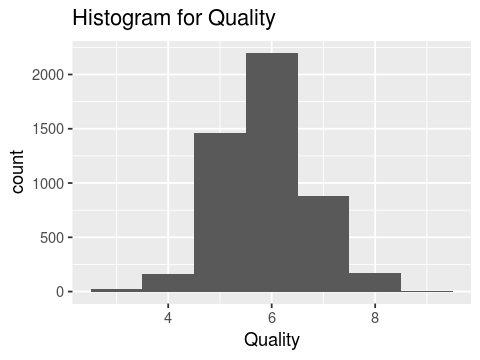

```r
# Histogram of quality
Quality = White_wine$quality
qplot(Quality,
      geom="histogram",
      main = "Histogram for Quality",binwidth=1)
options(repr.plot.width = 4, repr.plot.height = 3)
```

For most of the wine in our dataset, quality falls between 5 and 7 which is a range for good wines. There are couple of exceptions as excellent wine(8 or above), and poor (4 or below)

### Wine Quality Summary :

```r
summary(White_wine$quality)
```

```
   Min. 1st Qu.  Median    Mean 3rd Qu.    Max.
  3.000   5.000   6.000   5.878   6.000   9.000
```

### Analyzing correlation between Quality and input variables

```r
cor(White_wine[,2:12], White_wine$quality)
```

| fixed.acidity | -0.113662831 |
| --- | --- |
| volatile.acidity | -0.194722969 |
| citric.acid | -0.009209091 |
| residual.sugar | -0.097576829 |
| chlorides | -0.209934411 |
| free.sulfur.dioxide | 0.008158067 |
| total.sulfur.dioxide | -0.174737218 |
| density | -0.307123313 |
| pH | 0.099427246 |
| sulphates | 0.053677877 |
| alcohol | 0.435574715 |

This shows that wine quality has positive correlation with alcohol and negative correlation with chlorides and density.

### Role of pH and Alcohal in White Wine Quality :

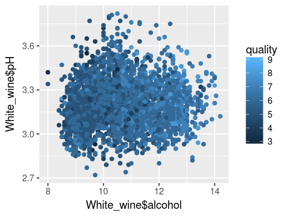

```r
ggplot(data= White_wine, aes(x = White_wine$alcohol, y = White_wine$pH, color = quality)) +
  geom_point()
```

It is difficult to find specific pattern in this figure since quality has a wide range.

#### Quality of wine into three categories of Poor, Good and Great to be able to differntiate patterns in each category.

```r
# Add a coloumn rating and label according to wine quality
White_wine$rating= ""
White_wine$rating[5 >= White_wine$quality ] = "Poor"
White_wine$rating[5< White_wine$quality & White_wine$quality < 7] = "Good"
White_wine$rating[7<= White_wine$quality ] = "Great"
White_wine$rating = as.factor(White_wine$rating)



head(White_wine)
```

| X | fixed.acidity | volatile.acidity | citric.acid | residual.sugar | chlorides | free.sulfur.dioxide | total.sulfur.dioxide | density | pH | sulphates | alcohol | quality | rating |
| --- | --- | --- | --- | --- | --- | --- | --- | --- | --- | --- | --- | --- | --- |
| 1 | 7.0 | 0.27 | 0.36 | 20.7 | 0.045 | 45 | 170 | 1.0010 | 3.00 | 0.45 | 8.8 | 6 | Good |
| 2 | 6.3 | 0.30 | 0.34 | 1.6 | 0.049 | 14 | 132 | 0.9940 | 3.30 | 0.49 | 9.5 | 6 | Good |
| 3 | 8.1 | 0.28 | 0.40 | 6.9 | 0.050 | 30 | 97 | 0.9951 | 3.26 | 0.44 | 10.1 | 6 | Good |
| 4 | 7.2 | 0.23 | 0.32 | 8.5 | 0.058 | 47 | 186 | 0.9956 | 3.19 | 0.40 | 9.9 | 6 | Good |
| 5 | 7.2 | 0.23 | 0.32 | 8.5 | 0.058 | 47 | 186 | 0.9956 | 3.19 | 0.40 | 9.9 | 6 | Good |
| 6 | 8.1 | 0.28 | 0.40 | 6.9 | 0.050 | 30 | 97 | 0.9951 | 3.26 | 0.44 | 10.1 | 6 | Good |

#### Displaying the White_Wine rating in tabular form with category and count.

```r
table(White_wine$rating)
```

```
 Good Great  Poor
 2198  1060  1640
```

#### How The Quality of Wines is Distributed Based On The Rating Introduced Above .

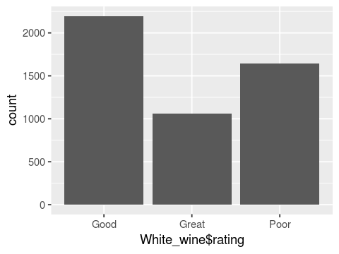

```r
ggplot(data = White_wine, aes(x = White_wine$rating)) +
  geom_bar()
```

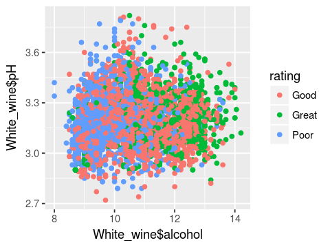

```r
ggplot(data= White_wine, aes(x = White_wine$alcohol, y = White_wine$pH, color = rating)) +
  geom_point()
```

According to the above scatter plot, there seems to be a relationship between alcohol percentage and rating of the wine. most of great wines are in the right side of the plot. More specifically, if the alcohol percentage is above 11% there seems to be a good chance that we will have a good or great wine (great wine has rating 7 or above, good ones has quality above 5). If it is more than 12% the chance is even higher.

However, to see the relationship better, in below chart I use only Alcohol and Quality to find out if there is actually a relationship between the two.

#### Relationship Between Alcohol and Quality

```r
#Add a label alcohalLabel
White_wine$alcoholLabel = ""
White_wine$alcoholLabel[White_wine$alcohol <= 9.5 ] = "Light"
White_wine$alcoholLabel[9.5< White_wine$alcohol & White_wine$quality <= 12] = "Mild"
White_wine$alcoholLabel[12< White_wine$alcohol ] = "Strong"
White_wine$alcoholLabel = as.factor(White_wine$alcoholLabel)

head(White_wine)
```

| X | fixed.acidity | volatile.acidity | citric.acid | residual.sugar | chlorides | free.sulfur.dioxide | total.sulfur.dioxide | density | pH | sulphates | alcohol | quality | rating | alcoholLabel |
| --- | --- | --- | --- | --- | --- | --- | --- | --- | --- | --- | --- | --- | --- | --- |
| 1 | 7.0 | 0.27 | 0.36 | 20.7 | 0.045 | 45 | 170 | 1.0010 | 3.00 | 0.45 | 8.8 | 6 | Good | Light |
| 2 | 6.3 | 0.30 | 0.34 | 1.6 | 0.049 | 14 | 132 | 0.9940 | 3.30 | 0.49 | 9.5 | 6 | Good | Light |
| 3 | 8.1 | 0.28 | 0.40 | 6.9 | 0.050 | 30 | 97 | 0.9951 | 3.26 | 0.44 | 10.1 | 6 | Good | Mild |
| 4 | 7.2 | 0.23 | 0.32 | 8.5 | 0.058 | 47 | 186 | 0.9956 | 3.19 | 0.40 | 9.9 | 6 | Good | Mild |
| 5 | 7.2 | 0.23 | 0.32 | 8.5 | 0.058 | 47 | 186 | 0.9956 | 3.19 | 0.40 | 9.9 | 6 | Good | Mild |
| 6 | 8.1 | 0.28 | 0.40 | 6.9 | 0.050 | 30 | 97 | 0.9951 | 3.26 | 0.44 | 10.1 | 6 | Good | Mild |

#### Displaying the White_Wine alcohalLabel in tabular form with category and count.

```r
table(White_wine$alcoholLabel)
```

```
 Light   Mild Strong
  1436   2751    711
```

#### Distribution of Alcohol Label Introduced Above

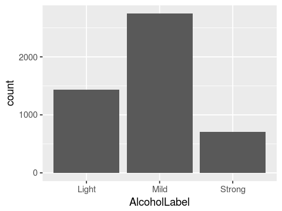

```r
AlcoholLabel = White_wine$alcoholLabel
ggplot(data = White_wine, aes(x = AlcoholLabel)) +
  geom_bar()
```

#### Histogram of Alcohol Percentage and Wine Quality

[figure not shown]

```r
ggplot(data= White_wine, aes(x=White_wine$quality , fill = White_wine$alcoholLabel)) +
  geom_histogram(aes(y=..count../sum(..count..))) +
  ggtitle("Histogram of Wine Quality and Alcohol Percent") +
  xlab("Wine Quality") + ylab("Percentage") +
  scale_y_continuous(labels = percent) +
  scale_fill_discrete(name="Alcohol Percentage")
```

As in the above stacked bar, for the higher quality wines there is more chance that the wine has higher alcohol percentage.

## Distribution of data: Wine Acidity

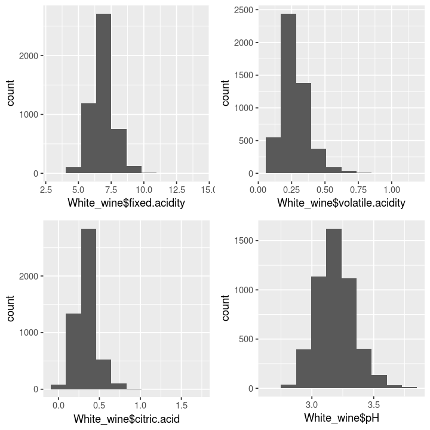

```r
g1 = ggplot(data = White_wine, aes(x=White_wine$fixed.acidity)) +
  geom_histogram(bins=10)

g2 = ggplot(data = White_wine, aes(x=White_wine$volatile.acidity)) +
  geom_histogram(bins=10)

g3 = ggplot(data = White_wine, aes(x=White_wine$citric.acid)) +
  geom_histogram(bins=10)

g4 = ggplot(data = White_wine, aes(x=White_wine$pH)) +
  geom_histogram(bins=10)
#options(repr.plot.width = 4, repr.plot.height = 3)

grid.newpage()
pushViewport(viewport(layout = grid.layout(2, 2)))

vplayout <- function(x, y) viewport(layout.pos.row = x, layout.pos.col = y)

print(g1, vp = vplayout(1, 1))
print(g2, vp = vplayout(1, 2))
print(g3, vp = vplayout(2, 1))
print(g4, vp = vplayout(2, 2))
```

Based on the bottom-right figure, wines are acidic and their pH are ranging from 2.5 to 4, however, most of wine have pH between 3 and 3.5.

Acidic nature of wines can come from three different types of acids:

1- Fixid acidity which is for most cases between 6 and 8.

2- Volatile Acidity which is mostly in range of .1 and .5

3- Citric Acidity which is ranging from 0 to 1 but for most of wines in our dataset is between .2 and .5

These features all seem to follow a normal distribution except Volatile Acidity which is slightly right skewed.

Log transformations to see if the result would be more bell-shaped:

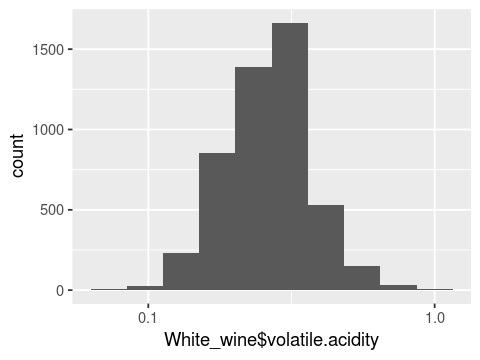

```r
#log transformation
ggplot(data = White_wine, aes(x=White_wine$volatile.acidity)) +
  geom_histogram(bins=10) +
  scale_x_log10()
options(repr.plot.width = 4, repr.plot.height = 3)
```

From the above graph we can see that log(volatile acidity) follows normal distribution.It is more like bell-shaped in logorithmic than regular,Therefore we will use the logarithmic transofomation for our further analysis.

```r
White_wine$volatile.acidity = log(White_wine$volatile.acidity)
```

### Distribution of data: Density, Chlorides, Sugar and Alcohol Percentage

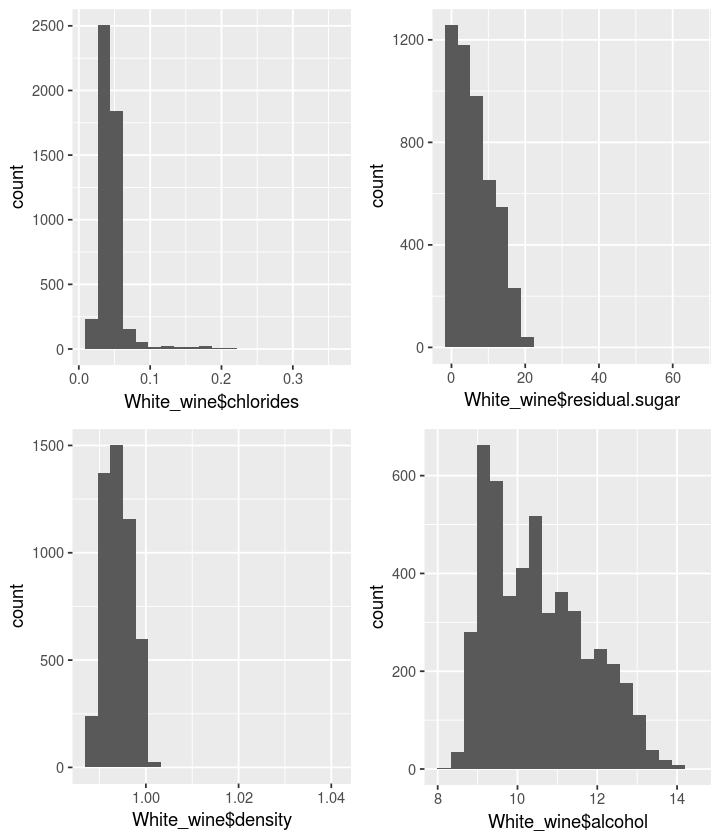

```r
g1 = ggplot(data = White_wine, aes(x=White_wine$chlorides)) +
  geom_histogram(bins=20)

g2 = ggplot(data = White_wine, aes(x=White_wine$residual.sugar)) +
  geom_histogram(bins=20)

g3 = ggplot(data = White_wine, aes(x=White_wine$density)) +
  geom_histogram(bins=20)

g4 = ggplot(data = White_wine, aes(x=White_wine$alcohol)) +
  geom_histogram(bins=20)

grid.newpage()
pushViewport(viewport(layout = grid.layout(2, 2)))


#vplayout <- function(x, y) viewport(layout.pos.row = x, layout.pos.col = y)


print(g1, vp = vplayout(1, 1))
print(g2, vp = vplayout(1, 2))
print(g3, vp = vplayout(2, 1))
print(g4, vp = vplayout(2, 2))
options(repr.plot.width = 6, repr.plot.height = 7)
```

Based on the above Graph, chlorides range in wines in our dataset is usually between 0 and .1 with some exceptions more than .1 g/dm^3.

The amount of sugar remained after fermentation is rarely more than 20 g/dm^3.

Density for wine are typically less than water but very slightly. The typical range for density would be (.99, 1)

Alcohol percentage in wine is varies between 8 and 14, however for most of the wines it is between 9 and 13.

Residual Sugar and Chlorides are highly right skewed. We will do logorithmic transformation in the next step:

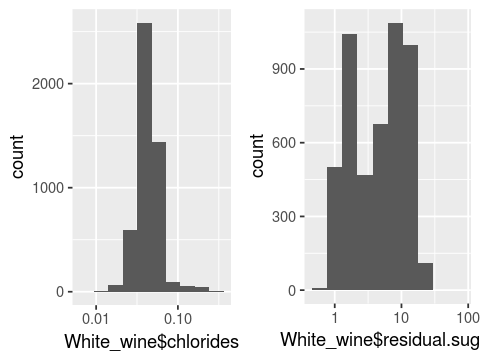

```r
g1 = ggplot(data = White_wine, aes(x=White_wine$chlorides)) +
  geom_histogram(bins=10) +
    scale_x_log10()

g2 = ggplot(data = White_wine, aes(x=White_wine$residual.sugar)) +
  geom_histogram(bins=10) +
    scale_x_log10() +
    #scale_x_log10()
#options(repr.plot.width = 4, repr.plot.height = 3)

grid.newpage()
pushViewport(viewport(layout = grid.layout(1, 2)))

print(g1, vp = vplayout(1, 1))
print(g2, vp = vplayout(1, 2))
```

Above Graph is more like bell-shaped. However, still Residual sugar is far from normal distribution as it seems like two different bell-shaped graph in the distribution.

### Relationship between density and alcohol percentage :

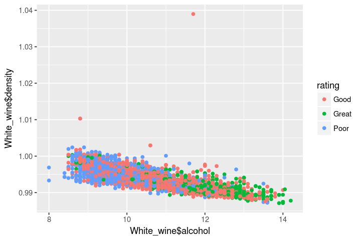

```r
ggplot(data = White_wine, aes(x = White_wine$alcohol, y = White_wine$density, color = rating)) +
  geom_point()
```

From the above plot it seems to be a correlation between density and alcohol percentage. Less dense, more alcohol. Also, great wines tend to be less dense.

### Relationship between Quality and Chlorides :

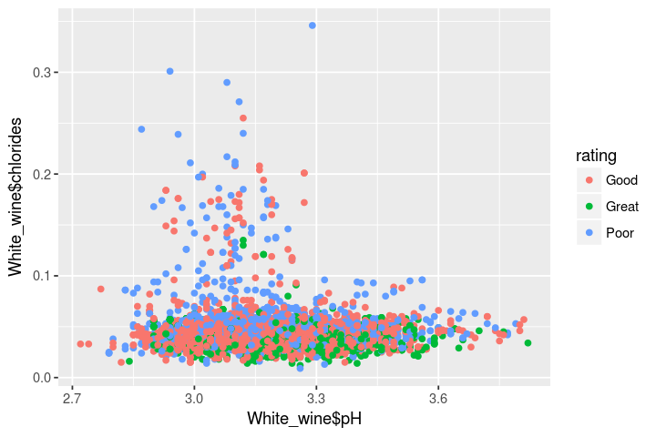

```r
ggplot(data = White_wine, aes(x = White_wine$pH, y = White_wine$chlorides, color = rating)) +
  geom_point()
```

From the above plot we can analyse that Wines with better quality tend to have less chlorides. If the chlorides level is higher than 0.050, there is a good chance the wine has worse rating.

## Conclusion :

Based on the above analysis that I did for this dataset, I am convinced that Alcohol percentage is the most important factor to decide the quality of White wine. One important factor that contributes to Alcohol percentage is the remaining sugar in wine after fermentation so that the more sugar left after fermentation, the less the percentage of alcohol will be in the wine and better quality tend to have less chlorides. If the chlorides level is higher than 0.050, there is a good chance the wine has worse rating.